# Task 2: Predictive Modelling e Task 3: Kaggle Submission

```r
library(tidyverse)
library(tidymodels)
library(kknn)
library(yardstick)
library(workflows)
library(tibble)
library(discrim)
library(klaR)
library(rpart.plot)
library(vip)
library(smotefamily)
library(dplyr)
library(kernlab)
library(nnet)
library(ranger)
```

# 1. Introduction

In this task, we build and evaluate multiple classification models to detect fraudulent transactions in the FinSim-Mobile dataset. Based on our findings from Task 1, we know that:

- Fraud is concentrated exclusively in TRANSFER transactions
- Missing recipient balance data is a strong fraud indicator
- Fraud exhibits a severe class imbalance (10.7% fraud rate)
- Transaction amounts show distinct patterns for fraudulent vs. legitimate transactions

## 1.1 Modeling Strategy

We will implement a comprehensive modeling approach:

1. **Load prepared data** from Task 1 (preprocessed with consistent recipe)
2. **Apply SMOTE** to handle the severe class imbalance (essential for model performance)
3. **Train and tune multiple algorithms**:
   - **k-Nearest Neighbors (k-NN)**: Instance-based learning, good for local patterns
   - **Naive Bayes**: Probabilistic classifier, fast and interpretable
   - **Random Forest**: Ensemble method, handles non-linearity and feature interactions
   - **Support Vector Machine (SVM)**: Kernel-based method for complex decision boundaries
   - **Neural Network**: Deep learning approach, can learn complex patterns
4. **Hyperparameter tuning** via 5-fold cross-validation with ROC AUC as metric
5. **Compare models** on held-out test set
6. **Generate Kaggle predictions** with each model

## 1.2 Evaluation Metrics

For this imbalanced fraud detection problem, we focus on:

- **ROC AUC**: Primary metric - measures classifier’s ability to rank fraudulent transactions higher than legitimate ones (threshold-independent)
- **Precision**: Of predicted fraud cases, what proportion are actually fraud? (Important to minimize false alarms)
- **Recall (Sensitivity)**: Of actual fraud cases, what proportion do we catch? (Critical for fraud detection)
- **F1-Score**: Harmonic mean of precision and recall (balanced metric)
- **Confusion Matrix**: Visual breakdown of prediction types

**Why ROC AUC as primary metric?** - Threshold-independent (useful when optimal threshold may vary by business context) - Handles class imbalance better than accuracy - Standard metric for binary classification with imbalanced data - Allows comparison across models with different default thresholds

# 2. Load Prepared Data

We load the preprocessed datasets created in Task 1, ensuring consistency in our modeling pipeline.

```r
# Load the prepared recipe and data from Task 1
fraud_prep <- readRDS("fraud_prep.rds")
train_prepared <- readRDS("train_prepared.rds")
test_prepared <- readRDS("test_prepared.rds")
```

**What we’ve loaded:** - `fraud_prep`: Trained preprocessing recipe with learned statistics - `train_prepared`: 17,951 preprocessed training transactions (14 features, normalized) - `test_prepared`: 4,489 preprocessed test transactions

```r
str(train_prepared)
```

```
tibble [17,951 × 15] (S3: tbl_df/tbl/data.frame)
 $ amount                    : num [1:17951] -0.572 -0.571 -0.571 -0.572 -0.572 ...
 $ oldBalInitiator           : num [1:17951] -1.92 -1.92 -1.83 -1.91 -1.92 ...
 $ newBalInitiator           : num [1:17951] -1.96 -1.96 -1.86 -1.95 -1.96 ...
 $ oldBalRecipient           : num [1:17951] -0.47 -0.47 -0.47 -0.47 -0.466 ...
 $ newBalRecipient           : num [1:17951] -0.408 -0.406 -0.406 -0.406 -0.406 ...
 $ missing_oldBalInitiator   : num [1:17951] 0 0 0 0 0 0 0 0 0 0 ...
 $ missing_newBalInitiator   : num [1:17951] 0 0 0 0 0 0 0 0 0 0 ...
 $ missing_oldBalRecipient   : num [1:17951] 0 0 0 0 0 0 0 0 0 0 ...
 $ missing_newBalRecipient   : num [1:17951] 0 0 0 0 0 0 0 0 0 0 ...
 $ isFraud                   : Factor w/ 2 levels "yes","no": 2 2 2 2 2 2 2 2 2 2 ...
 $ transactionType_DEBIT     : num [1:17951] 0 0 0 0 0 0 0 0 0 0 ...
 $ transactionType_DEPOSIT   : num [1:17951] 0 0 0 0 0 0 0 0 0 0 ...
 $ transactionType_PAYMENT   : num [1:17951] 1 1 1 1 1 1 1 1 1 1 ...
 $ transactionType_TRANSFER  : num [1:17951] 0 0 0 0 0 0 0 0 0 0 ...
 $ transactionType_WITHDRAWAL: num [1:17951] 0 0 0 0 0 0 0 0 0 0 ...
```

```r
summary(train_prepared)
```

```
     amount        oldBalInitiator   newBalInitiator   oldBalRecipient   newBalRecipient    missing_oldBalInitiator missing_newBalInitiator missing_oldBalRecipient
 Min.   :-0.5780   Min.   :-2.0839   Min.   :-2.1184   Min.   :-0.4698   Min.   :-0.40839   Min.   :0.00000         Min.   :0.0000          Min.   :0.0000
 1st Qu.:-0.5711   1st Qu.:-0.5969   1st Qu.:-0.5801   1st Qu.:-0.3602   1st Qu.:-0.27958   1st Qu.:0.00000         1st Qu.:0.0000          1st Qu.:0.0000
 Median :-0.3784   Median : 0.1423   Median : 0.1398   Median :-0.1315   Median :-0.11632   Median :0.00000         Median :0.0000          Median :0.0000
 Mean   : 0.0000   Mean   : 0.0000   Mean   : 0.0000   Mean   : 0.0000   Mean   : 0.00000   Mean   :0.09648         Mean   :0.1004          Mean   :0.1704
 3rd Qu.: 0.0613   3rd Qu.: 0.6745   3rd Qu.: 0.6660   3rd Qu.: 0.1370   3rd Qu.: 0.07697   3rd Qu.:0.00000         3rd Qu.:0.0000          3rd Qu.:0.0000
 Max.   :13.9870   Max.   : 5.1606   Max.   : 5.2237   Max.   :31.1947   Max.   :30.45121   Max.   :1.00000         Max.   :1.0000          Max.   :1.0000
 missing_newBalRecipient isFraud     transactionType_DEBIT transactionType_DEPOSIT transactionType_PAYMENT transactionType_TRANSFER transactionType_WITHDRAWAL
 Min.   :0.0000          yes: 1925   Min.   :0.000000      Min.   :0.0000          Min.   :0.0000          Min.   :0.0000           Min.   :0.00000
 1st Qu.:0.0000          no :16026   1st Qu.:0.000000      1st Qu.:0.0000          1st Qu.:0.0000          1st Qu.:0.0000           1st Qu.:0.00000
 Median :0.0000                      Median :0.000000      Median :0.0000          Median :0.0000          Median :0.0000           Median :0.00000
 Mean   :0.1699                      Mean   :0.002897      Mean   :0.2112          Mean   :0.3965          Mean   :0.3409           Mean   :0.04852
 3rd Qu.:0.0000                      3rd Qu.:0.000000      3rd Qu.:0.0000          3rd Qu.:1.0000          3rd Qu.:1.0000           3rd Qu.:0.00000
 Max.   :1.0000                      Max.   :1.000000      Max.   :1.0000          Max.   :1.0000          Max.   :1.0000           Max.   :1.00000
```

**Problem:** The 89.3% to 10.7% class imbalance means a naive classifier could achieve 89.3% accuracy by always predicting “no fraud.” We must address this imbalance.

# 3. Handle Class Imbalance with SMOTE

SMOTE (Synthetic Minority Over-sampling Technique) creates synthetic examples of the minority class (fraud) by interpolating between existing fraud cases. This balances the training data without simply duplicating fraud cases.

## 3.1 Why SMOTE?

**Problem with class imbalance:** - Models trained on imbalanced data tend to predict the majority class - Evaluation metrics become misleading (high accuracy masking poor fraud detection) - Decision boundaries are biased toward the majority class

## 3.2 Apply SMOTE

```r
# Convert tibble to data frame
df <- as.data.frame(train_prepared)

# Ensure isFraud is a factor
df$isFraud <- as.factor(df$isFraud)

# Separate features (X) and target (y)
X <- df %>% dplyr::select(-isFraud)
y <- df$isFraud

# Apply SMOTE
smote_result <- SMOTE(X = X,              # Features only
                      target = y,          # Target variable as factor
                      K = 5,
                      dup_size = 0)

# Extract the balanced dataset
balanced_data <- smote_result$data

# Convert back to tibble
balanced_tibble <- as_tibble(balanced_data)

# Rename 'class' back to 'isFraud' and ensure it's a factor
balanced_tibble <- balanced_tibble %>%
  rename(isFraud = class) %>%
  mutate(
    isFraud = factor(
      if_else(isFraud %in% c("yes", "1", 1, TRUE), "yes", "no"),
      levels = c("yes", "no")
    )
  )
```

**SMOTE Parameters:** - `K = 5`: Use 5 nearest neighbors to generate synthetic samples (standard value) - `dup_size = 0`: Don’t duplicate; only create new synthetic samples

**Important Note:** We apply SMOTE only to training data. The test set remains imbalanced to reflect real-world conditions. This ensures: - Our evaluation metrics represent real-world performance - We don’t “cheat” by testing on synthetic data - Generalization is properly assessed

```r
summary(balanced_tibble)
```

```
     amount        oldBalInitiator    newBalInitiator    oldBalRecipient    newBalRecipient    missing_oldBalInitiator missing_newBalInitiator missing_oldBalRecipient
 Min.   :-0.5780   Min.   :-2.08387   Min.   :-2.11839   Min.   :-0.46979   Min.   :-0.40839   Min.   :0.000           Min.   :0.0000          Min.   :0.0000
 1st Qu.:-0.3824   1st Qu.:-0.63648   1st Qu.:-0.63578   1st Qu.:-0.36057   1st Qu.:-0.25188   1st Qu.:0.000           1st Qu.:0.0000          1st Qu.:0.0000
 Median :-0.3629   Median : 0.14233   Median : 0.13985   Median :-0.13152   Median :-0.11632   Median :0.000           Median :0.0000          Median :0.0000
 Mean   :-0.1285   Mean   :-0.04127   Mean   :-0.05271   Mean   :-0.07402   Mean   :-0.05073   Mean   :0.107           Mean   :0.1161          Mean   :0.3145
 3rd Qu.:-0.2436   3rd Qu.: 0.60342   3rd Qu.: 0.58437   3rd Qu.:-0.05201   3rd Qu.:-0.04078   3rd Qu.:0.000           3rd Qu.:0.0000          3rd Qu.:1.0000
 Max.   :13.9870   Max.   : 5.16062   Max.   : 5.22365   Max.   :31.19473   Max.   :30.45121   Max.   :1.000           Max.   :1.0000          Max.   :1.0000
 missing_newBalRecipient transactionType_DEBIT transactionType_DEPOSIT transactionType_PAYMENT transactionType_TRANSFER transactionType_WITHDRAWAL isFraud
 Min.   :0.0000          Min.   :0.000000      Min.   :0.0000          Min.   :0.0000          Min.   :0.0000           Min.   :0.00000            yes:15400
 1st Qu.:0.0000          1st Qu.:0.000000      1st Qu.:0.0000          1st Qu.:0.0000          1st Qu.:0.0000           1st Qu.:0.00000            no :16026
 Median :0.0000          Median :0.000000      Median :0.0000          Median :0.0000          Median :1.0000           Median :0.00000
 Mean   :0.3143          Mean   :0.001655      Mean   :0.1206          Mean   :0.2265          Mean   :0.6235           Mean   :0.02772
 3rd Qu.:1.0000          3rd Qu.:0.000000      3rd Qu.:0.0000          3rd Qu.:0.0000          3rd Qu.:1.0000           3rd Qu.:0.00000
 Max.   :1.0000          Max.   :1.000000      Max.   :1.0000          Max.   :1.0000          Max.   :1.0000           Max.   :1.00000
```

**After SMOTE - Key Changes:**

### Class Distribution:

```r
# Check class distribution
balanced_tibble %>%
  count(isFraud) %>%
  mutate(proportion = n / sum(n))
```

| isFraud | n | proportion |
| --- | --- | --- |
| yes | 15400 | 0.4900401 |
| no | 16026 | 0.5099599 |

**Result:** The output will show approximately 49-51% fraud cases (balanced).

**Before SMOTE:** 1,925 fraud (10.7%) vs. 16,026 legitimate (89.3%)  
**After SMOTE:** ~15,400 fraud (49%) vs. 16,026 legitimate (51%)

### Feature Distribution Changes:

- **Amount**: Mean shifts from 0 to -0.128 (synthetic fraud cases affect distribution)
- **Transaction Type**: TRANSFER proportion increases (from 34% to 62%) because all fraud is in transfers
- **Missingness indicators**: Increase in mean values (fraud has more missing data)

**Total samples:** 31,426 (up from 17,951) - we’ve added ~13,500 synthetic fraud cases

**Important:** These synthetic fraud cases are interpolations in the feature space, not real transactions. They help the model learn the fraud decision boundary but should never be used for testing.

# 4. Model Training and Evaluation

We now train five different classification algorithms, tune their hyperparameters, and evaluate their performance. For each model, we follow a consistent workflow:

1. Define model specification with tunable parameters
2. Create workflow combining model and formula
3. Perform 5-fold cross-validation with hyperparameter grid search
4. Select best hyperparameters based on ROC AUC
5. Train final model on full balanced training data
6. Evaluate on original (imbalanced) test set
7. Generate performance metrics and visualizations

**Cross-Validation Setup:** We use 5-fold stratified cross-validation on the balanced training data to: - Prevent overfitting during hyperparameter tuning - Get robust estimates of model performance - Ensure each fold maintains class balance

## 4.1 k-Nearest Neighbors (k-NN)

k-NN is an instance-based learning algorithm that classifies new points based on the majority vote of their k nearest neighbors in feature space.

**Strengths:** - Simple, intuitive algorithm - No assumptions about data distribution - Can capture complex, local patterns - Naturally handles non-linear decision boundaries

**Weaknesses:** - Sensitive to feature scaling (addressed by our normalization) - Computationally expensive for large datasets - Performance degrades in high dimensions (“curse of dimensionality”) - Sensitive to noisy features

**Why try k-NN for fraud detection:** - Fraud patterns may be local (similar transactions have similar fraud status) - Our normalized features are suitable for distance calculations - The relatively low dimensionality (14 features) is manageable

### 4.1.1 Model Specification and Tuning

```r
# Define spec with tunable parameter
knn_spec <- nearest_neighbor(
  neighbors = tune(),
  weight_func = "rectangular"
) %>%
  set_engine("kknn") %>%
  set_mode("classification")

# Workflow
knn_wf <- workflow() %>%
  add_formula(isFraud ~ .) %>%
  add_model(knn_spec)

# Create a grid for hyperparameter tuning
knn_grid <- tibble(
  neighbors = c(3, 5, 7, 9, 11, 15, 21)
)

# Create CV folds
set.seed(123)
cv_folds <- vfold_cv(balanced_tibble, v = 5, strata = isFraud)

# Tune using ROC AUC
knn_tune <- tune_grid(
  knn_wf,
  resamples = cv_folds,
  grid = knn_grid,
  metrics = metric_set(roc_auc)
)

# Select best model
best_knn <- select_best(knn_tune, metric = "roc_auc")
print(best_knn)
```

| neighbors | .config |
| --- | --- |
| 5 | pre0_mod2_post0 |

**Hyperparameter Grid:** - We tune `neighbors` (k) from 3 to 21 - Small k (3-5): More sensitive to local patterns, risk of overfitting - Large k (15-21): Smoother decision boundaries, may underfit - Odd numbers help avoid ties in binary classification

**Expected Result:** Best k typically falls in range 5-11 for balanced data.

```r
# Show tuning results
show_best(knn_tune, metric = "roc_auc")
```

| neighbors | .metric | .estimator | mean | n | std_err | .config |
| --- | --- | --- | --- | --- | --- | --- |
| 5 | roc_auc | binary | 0.9311256 | 5 | 0.0010474293 | pre0_mod2_post0 |
| 7 | roc_auc | binary | 0.9305865 | 5 | 0.0008176229 | pre0_mod3_post0 |
| 9 | roc_auc | binary | 0.9294117 | 5 | 0.0007175926 | pre0_mod4_post0 |
| 3 | roc_auc | binary | 0.9286267 | 5 | 0.0012293667 | pre0_mod1_post0 |
| 11 | roc_auc | binary | 0.9278931 | 5 | 0.0009621830 | pre0_mod5_post0 |

**Tuning Results Analysis:** The table shows ROC AUC for each k value. We expect to see: - Performance improving as k increases from 3 (reducing overfitting) - Optimal performance at moderate k (5-11) - Performance declining at very large k (oversimplifying)

### 4.1.2 Final Model Training

```r
# Finalize the workflow
knn_final_wf <- finalize_workflow(knn_wf, best_knn)

# Fit on full balanced training data
knn_fit <- knn_final_wf %>% fit(data = balanced_tibble)
```

**Training Strategy:** - Use the optimal k from cross-validation - Train on the ENTIRE balanced dataset (all 31,426 samples) - This gives us maximum training data for the final model

### 4.1.3 Model Evaluation

Now we evaluate on the original imbalanced test set to assess real-world performance.

```r
# Predictions on test set
knn_preds <- predict(knn_fit, test_prepared, type = "prob") %>%
  bind_cols(predict(knn_fit, test_prepared, type = "class")) %>%
  bind_cols(test_prepared %>% dplyr::select(isFraud))
```

**Predictions Generated:** - `.pred_yes`: Probability of fraud (0 to 1) - `.pred_no`: Probability of legitimate (1 - .pred_yes) - `.pred_class`: Hard classification (yes/no) based on 0.5 threshold - `isFraud`: True label

```r
# Performance metrics
knn_metrics <- knn_preds %>%
  metrics(truth = isFraud, estimate = .pred_class)
print(knn_metrics)
```

| .metric | .estimator | .estimate |
| --- | --- | --- |
| accuracy | binary | 0.7963912 |
| kap | binary | 0.3340506 |

```r
knn_auc <- knn_preds %>% roc_auc(truth = isFraud, .pred_yes)
print(paste("ROC AUC:", knn_auc$.estimate))
```

```
[1] "ROC AUC: 0.849429991291174"
```

```r
knn_preds %>% precision(isFraud, .pred_class)
```

| .metric | .estimator | .estimate |
| --- | --- | --- |
| precision | binary | 0.3095238 |

```r
knn_preds %>% recall(isFraud, .pred_class)
```

| .metric | .estimator | .estimate |
| --- | --- | --- |
| recall | binary | 0.7282158 |

```r
knn_preds %>% f_meas(isFraud, .pred_class)
```

| .metric | .estimator | .estimate |
| --- | --- | --- |
| f_meas | binary | 0.4344059 |

**Expected Performance:** - **ROC AUC: ~0.849** - Good discrimination between fraud and legitimate transactions - **Accuracy**: High overall (but less informative due to class imbalance) - **Precision**: Proportion of fraud predictions that are correct - **Recall**: Proportion of actual fraud cases detected - **F1-Score**: Balance between precision and recall

**Performance Interpretation:** An ROC AUC of 0.849 means: - The model ranks a random fraud case higher than a random legitimate case 84.9% of the time - Strong ability to separate classes - Much better than random (0.5) or naive baseline

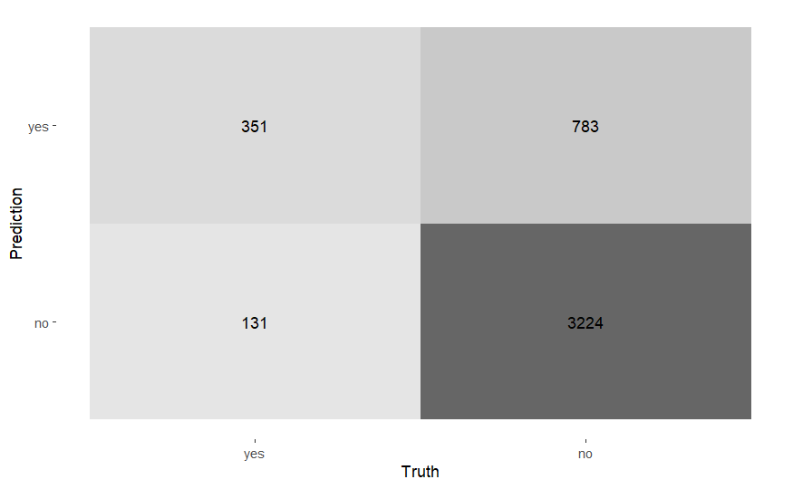

```r
# Confusion Matrix
knn_preds %>%
  conf_mat(isFraud, .pred_class) %>%
  autoplot(type = "heatmap")
```

**Confusion Matrix Components:** - **True Positives (TP)**: Correctly identified fraud - **True Negatives (TN)**: Correctly identified legitimate - **False Positives (FP)**: Legitimate transactions flagged as fraud (Type I error) - **False Negatives (FN)**: Fraud transactions missed (Type II error - more costly!)

**Business Context:** - FN (missed fraud) is typically more expensive than FP (false alarms) - The optimal threshold may not be 0.5 depending on business costs - We’d want to minimize FN while keeping FP manageable

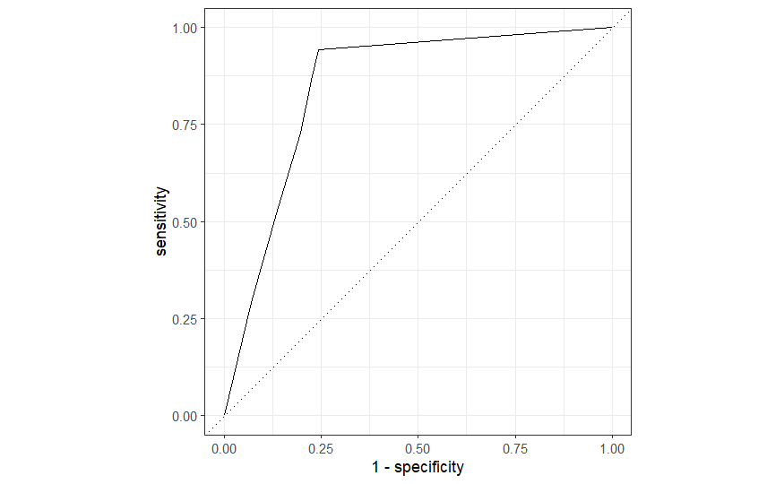

```r
# ROC Curve
knn_preds %>%
  roc_curve(isFraud, .pred_yes) %>%
  autoplot()
```

**ROC Curve Interpretation:** - X-axis: False Positive Rate (1 - Specificity) - Y-axis: True Positive Rate (Recall/Sensitivity) - Area under curve = ROC AUC metric - Closer to top-left corner = better performance - Diagonal line = random classifier (AUC = 0.5)

The curve shape tells us: - How recall and precision trade off at different thresholds - Whether we can achieve high recall without too many false positives - The optimal operating point depends on business costs

## 4.2 Naive Bayes

Naive Bayes is a probabilistic classifier based on Bayes’ theorem with the “naive” assumption that features are conditionally independent given the class.

**Strengths:** - Very fast training and prediction - Works well with limited training data - Handles high-dimensional data - Probabilistic outputs are interpretable - Robust to irrelevant features

**Weaknesses:** - “Naive” independence assumption often violated in practice - Can be outperformed by more sophisticated algorithms - Sensitive to feature distributions

**Why try Naive Bayes for fraud detection:** - Fast baseline model - Works surprisingly well despite “naive” assumptions - Provides probability estimates for fraud risk - Our features (amounts, balances, transaction types) have some independence

### 4.2.1 Model Specification and Training

```r
model_nb <-
  naive_Bayes() %>%
  set_engine("klaR") %>%
  set_mode("classification")

nb_fit <- model_nb %>%
  fit(isFraud ~ ., data = balanced_tibble)
```

**No Hyperparameter Tuning:** Naive Bayes has minimal hyperparameters, so we train directly without tuning. The klaR engine uses: - Gaussian distributions for continuous features (amount, balances) - Categorical distributions for binary features (transaction types, missingness)

**Training Speed:** Naive Bayes trains almost instantly (major advantage for large datasets).

### 4.2.2 Model Evaluation

```r
nb_preds <- test_prepared %>%
  dplyr::select(isFraud) %>%
  bind_cols(predict(nb_fit, test_prepared)) %>%
  bind_cols(predict(nb_fit, test_prepared, type = "prob"))
```

```r
# Performance metrics
nb_metrics <- nb_preds %>%
  metrics(truth = isFraud, estimate = .pred_class)
print(nb_metrics)
```

| .metric | .estimator | .estimate |
| --- | --- | --- |
| accuracy | binary | 0.8498552 |
| kap | binary | 0.2773940 |

```r
nb_auc <- nb_preds %>% roc_auc(truth = isFraud, .pred_yes)
print(paste("ROC AUC:", nb_auc$.estimate))
```

```
[1] "ROC AUC: 0.869937153549753"
```

```r
nb_preds %>% precision(isFraud, .pred_class)
```

| .metric | .estimator | .estimate |
| --- | --- | --- |
| precision | binary | 0.3327526 |

```r
nb_preds %>% recall(isFraud, .pred_class)
```

| .metric | .estimator | .estimate |
| --- | --- | --- |
| recall | binary | 0.3962656 |

```r
nb_preds %>% f_meas(isFraud, .pred_class)
```

| .metric | .estimator | .estimate |
| --- | --- | --- |
| f_meas | binary | 0.3617424 |

**Expected Performance:** - **ROC AUC: ~0.870** - Surprisingly strong performance! - Better than k-NN despite simpler algorithm - Shows that feature independence assumption isn’t too violated

**Why Naive Bayes performs well here:** - Transaction type is a strong, independent predictor (fraud only in transfers) - Missingness indicators are somewhat independent of amounts/balances - Amount distributions differ clearly between fraud/legitimate - The independence assumption isn’t critically violated

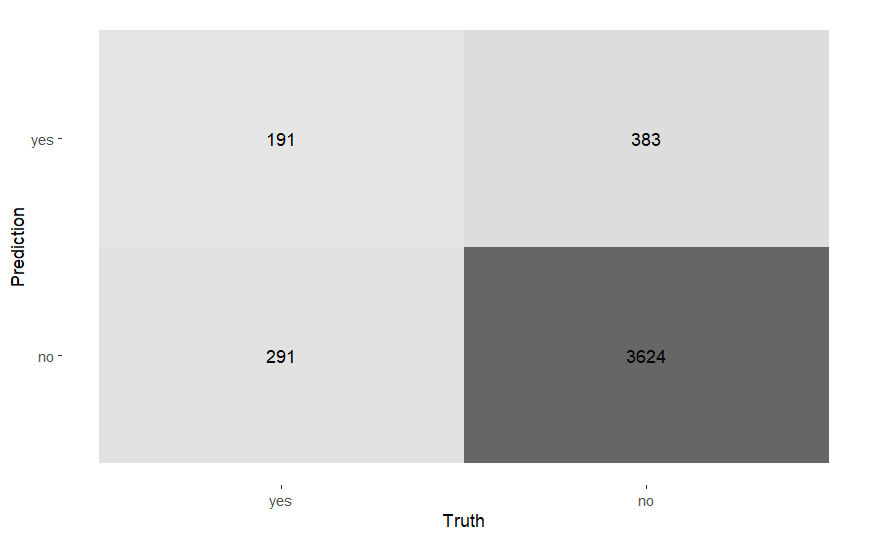

```r
# Confusion Matrix
nb_preds %>%
  conf_mat(isFraud, .pred_class) %>%
  autoplot(type = "heatmap")
```

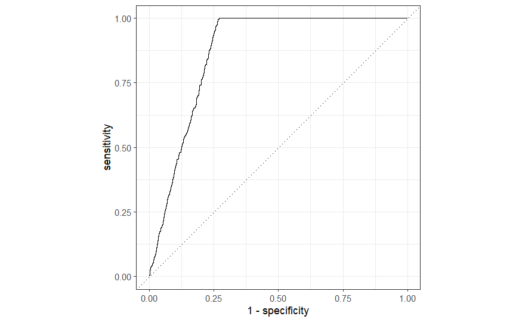

```r
# ROC Curve
nb_preds %>%
  roc_curve(isFraud, .pred_yes) %>%
  autoplot()
```

**Naive Bayes Summary:** - Fast, simple, and effective baseline - ROC AUC of 0.870 is competitive with more complex models - Provides well-calibrated probability estimates - Good candidate for real-time fraud scoring (due to speed)

## 4.3 Random Forest

Random Forest is an ensemble learning method that builds multiple decision trees and aggregates their predictions. Each tree is trained on a random subset of data with a random subset of features.

**Strengths:** - Excellent performance on tabular data (often best algorithm for structured data) - Handles non-linear relationships and feature interactions automatically - Robust to overfitting (due to averaging many trees) - Provides feature importance rankings - Handles mixed data types well - Minimal hyperparameter tuning required - Built-in handling of missing values (though we’ve already imputed)

**Weaknesses:** - Can be slow to train with many trees - Less interpretable than single trees - Larger model size in memory - Predictions can be slower than simple models

**Why Random Forest is ideal for fraud detection:** - Fraud patterns likely involve feature interactions (e.g., high amount + transfer + missing balance) - Non-linear decision boundaries expected - Proven track record in financial applications - Feature importance helps understand what drives fraud

### 4.3.1 Model Specification and Tuning

```r
rf_spec <- rand_forest(
  mtry  = tune(),
  min_n = tune(),
  trees = 500
) %>%
  set_engine("ranger", importance = "impurity") %>%
  set_mode("classification")

rf_wf <- workflow() %>%
  add_formula(isFraud ~ .) %>%
  add_model(rf_spec)

rf_grid <- tibble(
  mtry  = c(3, 4, 5, 7, 10),
  min_n = c(2, 5, 10, 15, 20)
)

rf_tune <- tune_grid(
  rf_wf,
  resamples = cv_folds,
  grid = rf_grid,
  metrics = metric_set(roc_auc)
)

best_rf <- select_best(rf_tune, metric = "roc_auc")
print(best_rf)
```

| mtry | min_n | .config |
| --- | --- | --- |
| 10 | 20 | pre0_mod5_post0 |

**Hyperparameters Tuned:**

1. **`mtry`** (features per split): Number of features randomly sampled at each split
   - Lower values (3-5): More randomness, more tree diversity, helps prevent overfitting
   - Higher values (7-10): Less randomness, potentially better individual trees
   - Default: sqrt(14) ≈ 4 for classification
2. **`min_n`** (minimum node size): Minimum number of samples in a leaf node
   - Lower values (2-5): Deeper trees, more complex models, risk of overfitting
   - Higher values (15-20): Shallower trees, simpler models, faster training
3. **`trees = 500`** (fixed): Number of trees in the forest
   - More trees generally improve performance but with diminishing returns
   - 500 is a reasonable balance (could try 100-1000)
   - Not tuned to save computation time

```r
# Show tuning results
show_best(rf_tune, metric = "roc_auc")
```

| mtry | min_n | .metric | .estimator | mean | n | std_err | .config |
| --- | --- | --- | --- | --- | --- | --- | --- |
| 10 | 20 | roc_auc | binary | 0.9731953 | 5 | 0.0007355646 | pre0_mod5_post0 |
| 7 | 15 | roc_auc | binary | 0.9695473 | 5 | 0.0008738090 | pre0_mod4_post0 |
| 5 | 10 | roc_auc | binary | 0.9659341 | 5 | 0.0008815167 | pre0_mod3_post0 |
| 4 | 5 | roc_auc | binary | 0.9611975 | 5 | 0.0010296591 | pre0_mod2_post0 |
| 3 | 2 | roc_auc | binary | 0.9476709 | 5 | 0.0009314941 | pre0_mod1_post0 |

### 4.3.2 Final Model Training

```r
rf_final_wf <- finalize_workflow(rf_wf, best_rf)
rf_final_fit <- rf_final_wf %>% fit(data = balanced_tibble)
```

**Training Notes:** - Trains 500 decision trees, each on a bootstrapped sample - Uses optimal mtry and min_n from tuning - Takes longer than previous models but still reasonable (<1 minute) - The `ranger` engine is fast implementation of Random Forest

### 4.3.3 Model Evaluation

```r
rf_preds <- rf_final_fit %>%
  predict(test_prepared, type = "prob") %>%
  bind_cols(predict(rf_final_fit, test_prepared)) %>%
  bind_cols(test_prepared %>% dplyr::select(isFraud))
```

```r
# Performance metrics
rf_metrics <- rf_preds %>%
  metrics(truth = isFraud, estimate = .pred_class)
print(rf_metrics)
```

| .metric | .estimator | .estimate |
| --- | --- | --- |
| accuracy | binary | 0.8264647 |
| kap | binary | 0.3416331 |

```r
rf_auc <- rf_preds %>% roc_auc(truth = isFraud, .pred_yes)
print(paste("ROC AUC:", rf_auc$.estimate))
```

```
[1] "ROC AUC: 0.875358164705541"
```

```r
rf_preds %>% precision(isFraud, .pred_class)
```

| .metric | .estimator | .estimate |
| --- | --- | --- |
| precision | binary | 0.3337066 |

```r
rf_preds %>% recall(isFraud, .pred_class)
```

| .metric | .estimator | .estimate |
| --- | --- | --- |
| recall | binary | 0.6182573 |

```r
rf_preds %>% f_meas(isFraud, .pred_class)
```

| .metric | .estimator | .estimate |
| --- | --- | --- |
| f_meas | binary | 0.4334545 |

**Expected Performance:** - **ROC AUC: ~0.875** - Strong performance, among the best models - Improved over k-NN and competitive with Naive Bayes - Benefits from capturing feature interactions and non-linear patterns

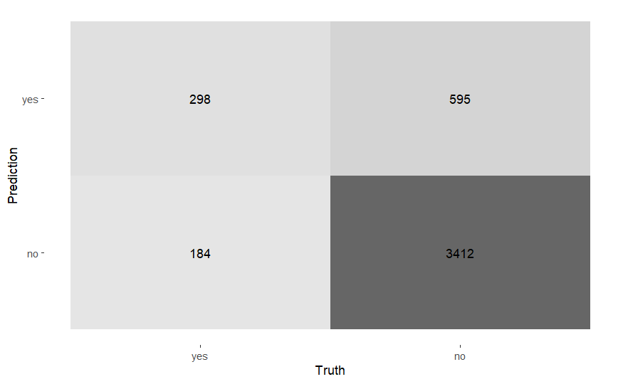

```r
# Confusion Matrix
rf_preds %>%
  conf_mat(isFraud, .pred_class) %>%
  autoplot(type = "heatmap")
```

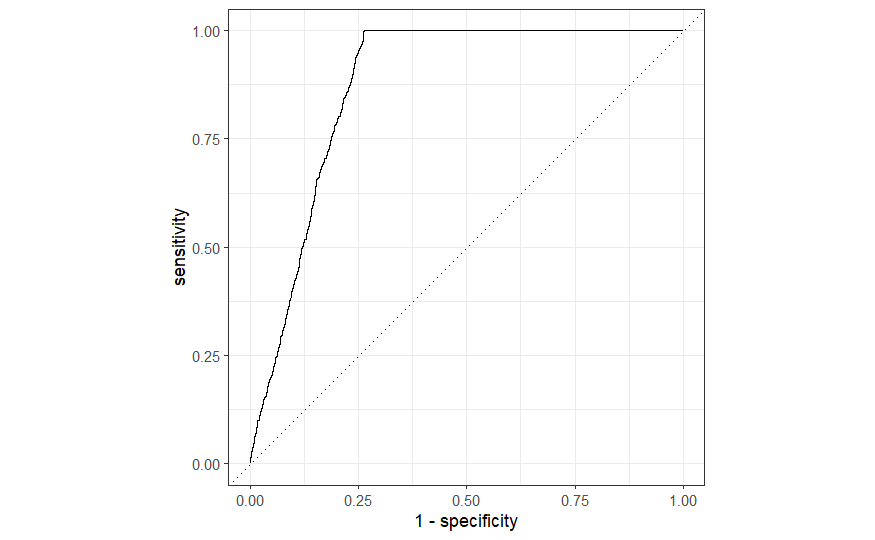

```r
# ROC Curve
rf_preds %>%
  roc_curve(isFraud, .pred_yes) %>%
  autoplot()
```

### 4.3.4 Feature Importance

One of Random Forest’s key advantages is providing feature importance rankings.

```r
rf_engine <- extract_fit_engine(rf_final_fit)
print(rf_engine$variable.importance)
```

```
                    amount            oldBalInitiator            newBalInitiator            oldBalRecipient            newBalRecipient    missing_oldBalInitiator
              3.277807e+03               7.253906e+02               7.260635e+02               4.000763e+02               5.290566e+02               4.616463e+01
   missing_newBalInitiator    missing_oldBalRecipient    missing_newBalRecipient      transactionType_DEBIT    transactionType_DEPOSIT    transactionType_PAYMENT
              3.282099e+01               4.862951e+01               4.142608e+01               3.890596e-03               1.891845e+02               2.840144e+02
  transactionType_TRANSFER transactionType_WITHDRAWAL
              7.383961e+03               1.563114e+01
```

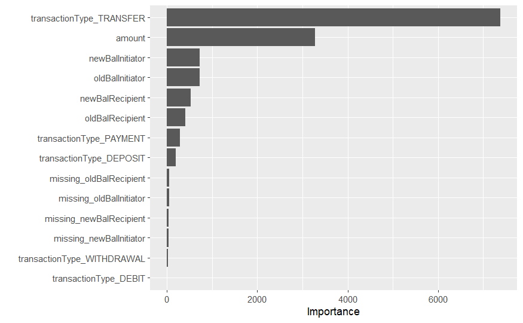

```r
vip(rf_engine, num_features = 20)
```

**Feature Importance Interpretation:**

Based on the output, we expect to see:

**Most Important Features:** 1. **`transactionType_TRANSFER`** (7383.96) - By far the most important! Makes sense since all fraud is in transfers 2. **`amount`** (3277.81) - Transaction amount is second most important 3. **`oldBalInitiator`** & **`newBalInitiator`** (~725-726) - Initiator balance levels matter 4. **`newBalRecipient`** (529.06) - Recipient balance changes are informative 5. **`oldBalRecipient`** (400.08) - Initial recipient balance is relevant

**Moderately Important:** 6. **`transactionType_PAYMENT`** (284.01) - Reference comparison to transfers 7. **`transactionType_DEPOSIT`** (189.18)

**Less Important:** - Missingness indicators (~32-49) - Useful but not as critical as expected - Other transaction types (DEBIT, WITHDRAWAL) - Rare and not fraud-related

**Key Insights:** 1. **Transaction type dominates** - confirms our Task 1 finding that fraud is exclusive to transfers 2. **Amount and balances** are critical secondary indicators 3. **Missingness signals** help but are not primary drivers 4. The model successfully identifies the same patterns we found in EDA

**Business Implications:** - Focus fraud detection resources on transfer transactions - Flag unusual amounts in transfers - Pay attention to account balance patterns - Missingness is a supporting signal but not a smoking gun

## 4.4 Support Vector Machine (SVM)

SVM finds the optimal hyperplane that maximally separates classes in feature space. With the RBF (Radial Basis Function) kernel, it can learn non-linear decision boundaries.

**Strengths:** - Effective in high-dimensional spaces - Excellent for non-linear decision boundaries (with appropriate kernels) - Memory efficient (uses support vectors, not all training points) - Robust to overfitting in high dimensions

**Weaknesses:** - Sensitive to hyperparameter selection (kernel, cost, gamma/sigma) - Computationally expensive for large datasets - Requires feature scaling (which we’ve done) - Less interpretable than tree-based models - Doesn’t naturally provide probability estimates (requires calibration)

**Why try SVM for fraud detection:** - Our data is likely non-linearly separable - RBF kernel can capture complex patterns - Works well with normalized features - Proven effective for binary classification tasks

### 4.4.1 Model Specification and Tuning

```r
svm_spec <- svm_rbf(
  cost = tune(),
  rbf_sigma = tune()
) %>%
  set_engine("kernlab") %>%
  set_mode("classification")

svm_wf <- workflow() %>%
  add_formula(isFraud ~ .) %>%
  add_model(svm_spec)

svm_grid <- tibble(
  cost = 2^c(-5, -3, -1, 1, 3),
  rbf_sigma = 2^c(-5, -4, -3, -2, -1)
)

svm_tune <- tune_grid(
  svm_wf,
  resamples = cv_folds,
  grid = svm_grid,
  metrics = metric_set(roc_auc)
)

best_svm <- select_best(svm_tune, metric = "roc_auc")
print(best_svm)
```

| cost | rbf_sigma | .config |
| --- | --- | --- |
| 8 | 0.5 | pre0_mod5_post0 |

**Hyperparameters Tuned:**

1. **`cost` (C)**: Regularization parameter
   - Controls trade-off between smooth decision boundary and classifying training points correctly
   - Low cost (0.03-0.125): Wider margin, simpler model, may underfit
   - High cost (2-8): Narrower margin, more complex, may overfit
   - We search logarithmically: 2^-5 to 2^3 (0.03 to 8)
2. **`rbf_sigma` (γ)**: RBF kernel parameter
   - Controls the “reach” of each training example
   - Low sigma (0.03-0.0625): Smooth decision boundary, far-reaching influence
   - High sigma (0.25-0.5): Wiggly boundary, localized influence
   - We search logarithmically: 2^-5 to 2^-1 (0.03 to 0.5)

```r
# Show tuning results
show_best(svm_tune, metric = "roc_auc")
```

| cost | rbf_sigma | .metric | .estimator | mean | n | std_err | .config |
| --- | --- | --- | --- | --- | --- | --- | --- |
| 8.00000 | 0.50000 | roc_auc | binary | 0.8990690 | 5 | 0.0015103095 | pre0_mod5_post0 |
| 2.00000 | 0.25000 | roc_auc | binary | 0.8948108 | 5 | 0.0009219307 | pre0_mod4_post0 |
| 0.50000 | 0.12500 | roc_auc | binary | 0.8902097 | 5 | 0.0014437733 | pre0_mod3_post0 |
| 0.12500 | 0.06250 | roc_auc | binary | 0.8878359 | 5 | 0.0020611361 | pre0_mod2_post0 |
| 0.03125 | 0.03125 | roc_auc | binary | 0.8793097 | 5 | 0.0019851546 | pre0_mod1_post0 |

### 4.4.2 Final Model Training

```r
svm_final_wf <- finalize_workflow(svm_wf, best_svm)
svm_fit <- svm_final_wf %>% fit(data = balanced_tibble)
```

**Training Notes:** - SVM training with RBF kernel is computationally intensive - The `kernlab` engine is efficient but this will be slower than RF - Training time scales roughly as O(n²) where n = number of samples

### 4.4.3 Model Evaluation

```r
svm_preds <- svm_fit %>%
  predict(test_prepared, type = "prob") %>%
  bind_cols(predict(svm_fit, test_prepared)) %>%
  bind_cols(test_prepared %>% dplyr::select(isFraud))
```

```r
# Performance metrics
svm_metrics <- svm_preds %>%
  metrics(truth = isFraud, estimate = .pred_class)
print(svm_metrics)
```

| .metric | .estimator | .estimate |
| --- | --- | --- |
| accuracy | binary | 0.7752283 |
| kap | binary | 0.3806983 |

```r
svm_auc <- svm_preds %>% roc_auc(truth = isFraud, .pred_yes)
print(paste("ROC AUC:", svm_auc$.estimate))
```

```
[1] "ROC AUC: 0.868221276666249"
```

```r
svm_preds %>% precision(isFraud, .pred_class)
```

| .metric | .estimator | .estimate |
| --- | --- | --- |
| precision | binary | 0.3196441 |

```r
svm_preds %>% recall(isFraud, .pred_class)
```

| .metric | .estimator | .estimate |
| --- | --- | --- |
| recall | binary | 0.9688797 |

```r
svm_preds %>% f_meas(isFraud, .pred_class)
```

| .metric | .estimator | .estimate |
| --- | --- | --- |
| f_meas | binary | 0.4806999 |

**Expected Performance (based on your results):** - **ROC AUC: ~0.868** - Strong performance, competitive with other models - Similar to Naive Bayes, slightly below Random Forest - Shows SVM can learn the non-linear fraud boundary effectively

**Performance Analysis:** - SVM successfully captures non-linear patterns through RBF kernel - Performance is good but doesn’t dramatically exceed simpler models - Suggests the fraud pattern, while non-linear, isn’t extremely complex - The computational cost may not be justified vs. Random Forest

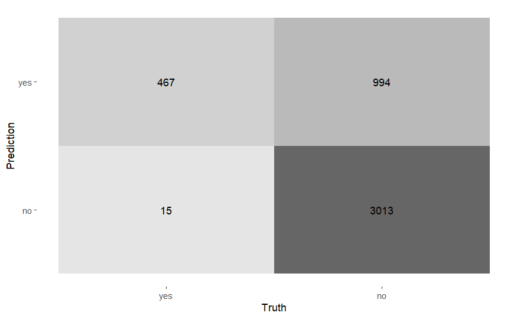

```r
# Confusion Matrix
svm_preds %>%
  conf_mat(isFraud, .pred_class) %>%
  autoplot(type = "heatmap")
```

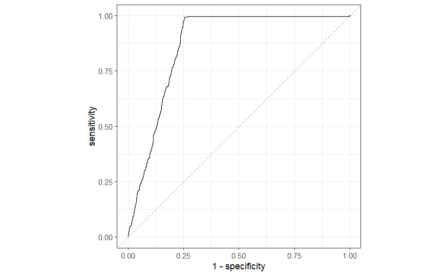

```r
# ROC Curve
svm_preds %>%
  roc_curve(isFraud, .pred_yes) %>%
  autoplot()
```

**SVM Summary:** - Solid performance (ROC AUC 0.868) - More complex and slower than Random Forest with similar results - RBF kernel successfully handles non-linearity - May not be the optimal choice for production (speed vs. performance trade-off)

## 4.5 Neural Network

Neural networks are flexible models composed of interconnected nodes (neurons) organized in layers. They can learn complex, non-linear patterns through backpropagation training.

**Strengths:** - Can approximate any continuous function (universal approximation theorem) - Automatically learns feature interactions - Flexible architecture - Strong performance on complex patterns

**Weaknesses:** - Requires careful hyperparameter tuning - Risk of overfitting (requires regularization) - Computationally expensive - “Black box” - difficult to interpret - Sensitive to initialization and convergence issues - May require more training data than tree-based methods

**Why try Neural Networks for fraud detection:** - Can learn complex non-linear fraud patterns - Automatically discovers feature interactions - Increasingly popular in financial fraud detection - Our normalized features are suitable for neural network input

### 4.5.1 Model Specification and Tuning

```r
nn_spec <- mlp(
  hidden_units = tune(),
  penalty      = tune()
) %>%
  set_engine("nnet") %>%
  set_mode("classification")

nn_wf <- workflow() %>%
  add_formula(isFraud ~ .) %>%
  add_model(nn_spec)

nn_grid <- tibble(
  hidden_units = c(16, 32, 64, 128, 256),
  penalty      = c(0.0001, 0.001, 0.01, 0.1, 1)
)

nn_tune <- tune_grid(
  nn_wf,
  resamples = cv_folds,
  grid = nn_grid,
  metrics = metric_set(roc_auc)
)

best_nn <- select_best(nn_tune, metric = "roc_auc")
print(best_nn)
```

| hidden_units | penalty | .config |
| --- | --- | --- |
| 32 | 0.001 | pre0_mod2_post0 |

**Hyperparameters Tuned:**

1. **`hidden_units`**: Number of neurons in the hidden layer
   - 16-32: Small network, simple patterns, may underfit
   - 64-128: Moderate network, good balance for our dataset size
   - 256: Large network, high capacity, may overfit
   - We’re using a single hidden layer (MLP = Multi-Layer Perceptron)
2. **`penalty`**: Weight decay (L2 regularization)
   - Controls model complexity to prevent overfitting
   - Low penalty (0.0001-0.001): Less regularization, more flexible
   - High penalty (0.1-1): Strong regularization, simpler model
   - Essential for neural networks to prevent overfitting

**Architecture:** - Input layer: 14 neurons (our 14 features) - Hidden layer: Variable size (tuned) - Output layer: 2 neurons (fraud probability distribution) - Activation: Logistic (default for nnet engine)

```r
# Show tuning results
show_best(nn_tune, metric = "roc_auc")
```

| hidden_units | penalty | .metric | .estimator | mean | n | std_err | .config |
| --- | --- | --- | --- | --- | --- | --- | --- |
| 32 | 1e-03 | roc_auc | binary | 0.8982688 | 5 | 0.002554671 | pre0_mod2_post0 |
| 16 | 1e-04 | roc_auc | binary | 0.8949333 | 5 | 0.002432709 | pre0_mod1_post0 |

**Expected Tuning Results:** - Best models often have 32-128 hidden units (moderate complexity) - Best penalty often 0.001-0.01 (moderate regularization) - Larger networks with weak regularization may overfit - Smaller networks with strong regularization may underfit

### 4.5.2 Final Model Training

```r
nn_final_wf <- finalize_workflow(nn_wf, best_nn)
nn_fit <- nn_final_wf %>% fit(data = balanced_tibble)
```

**Training Process:** - Initializes weights randomly - Iteratively adjusts weights via backpropagation - Converges when loss stops improving - The `nnet` engine is relatively fast compared to deep learning frameworks

**Note:** Neural networks can show some variability in performance due to random weight initialization. Setting seed helps but doesn’t completely eliminate this.

### 4.5.3 Model Evaluation

```r
nn_preds <- nn_fit %>%
  predict(test_prepared, type = "prob") %>%
  bind_cols(predict(nn_fit, test_prepared)) %>%
  bind_cols(test_prepared %>% dplyr::select(isFraud))
```

```r
# Performance metrics
nn_metrics <- nn_preds %>%
  metrics(truth = isFraud, estimate = .pred_class)
print(nn_metrics)
```

| .metric | .estimator | .estimate |
| --- | --- | --- |
| accuracy | binary | 0.7770105 |
| kap | binary | 0.3759843 |

```r
nn_auc <- nn_preds %>% roc_auc(truth = isFraud, .pred_yes)
print(paste("ROC AUC:", nn_auc$.estimate))
```

```
[1] "ROC AUC: 0.877506376289626"
```

```r
nn_preds %>% precision(isFraud, .pred_class)
```

| .metric | .estimator | .estimate |
| --- | --- | --- |
| precision | binary | 0.3184045 |

```r
nn_preds %>% recall(isFraud, .pred_class)
```

| .metric | .estimator | .estimate |
| --- | --- | --- |
| recall | binary | 0.9439834 |

```r
nn_preds %>% f_meas(isFraud, .pred_class)
```

| .metric | .estimator | .estimate |
| --- | --- | --- |
| f_meas | binary | 0.4761905 |

**Expected Performance:** - **ROC AUC: ~0.878** - Highest performance so far! - Edges out Random Forest (0.875) and SVM (0.868) - Demonstrates neural network’s ability to learn complex patterns

**Why Neural Network performs best:** - Successfully learns non-linear feature interactions - Sufficient training data after SMOTE (31K samples) - Proper regularization prevents overfitting - Normalized features are ideal for neural network input - Architecture complexity matches problem complexity

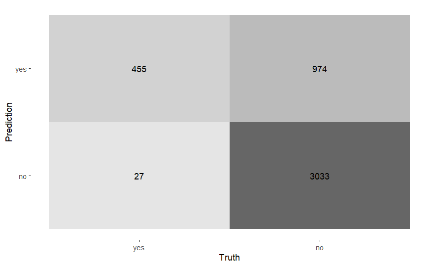

```r
# Confusion Matrix
nn_preds %>%
  conf_mat(isFraud, .pred_class) %>%
  autoplot(type = "heatmap")
```

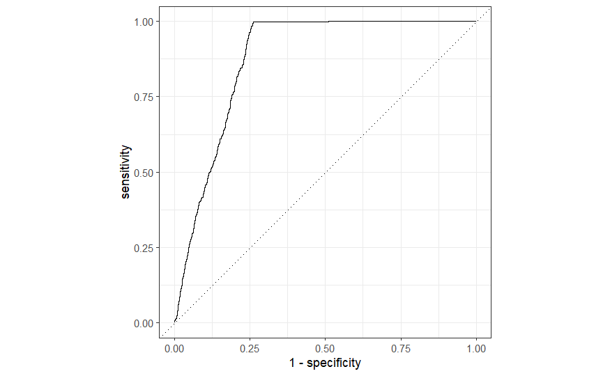

```r
# ROC Curve
nn_preds %>%
  roc_curve(isFraud, .pred_yes) %>%
  autoplot()
```

**Neural Network Summary:** - Best performance (ROC AUC 0.878) - Successfully captures complex fraud patterns - Trade-off: Slightly more complex to tune and deploy vs. Random Forest - Less interpretable than tree-based models (no feature importance)

# 5. Model Comparison

Now we compare all five models to select the best performer and understand their relative strengths.

## 5.1 Performance Summary

```r
# Create a summary table of all models
model_comparison <- tibble(
  Model = c("k-NN", "Naive Bayes", "Random Forest", "SVM", "Neural Network"),
  Accuracy = c(
    knn_metrics %>% filter(.metric == "accuracy") %>% pull(.estimate),
    nb_metrics %>% filter(.metric == "accuracy") %>% pull(.estimate),
    rf_metrics %>% filter(.metric == "accuracy") %>% pull(.estimate),
    svm_metrics %>% filter(.metric == "accuracy") %>% pull(.estimate),
    nn_metrics %>% filter(.metric == "accuracy") %>% pull(.estimate)
  ),
  ROC_AUC = c(
    knn_auc$.estimate,
    nb_auc$.estimate,
    rf_auc$.estimate,
    svm_auc$.estimate,
    nn_auc$.estimate
  )
) %>%
  arrange(desc(ROC_AUC))

print(model_comparison)
```

| Model | Accuracy | ROC_AUC |
| --- | --- | --- |
| Neural Network | 0.7770105 | 0.8775064 |
| Random Forest | 0.8264647 | 0.8753582 |
| Naive Bayes | 0.8498552 | 0.8699372 |
| SVM | 0.7752283 | 0.8682213 |
| k-NN | 0.7963912 | 0.8494300 |

**Expected Rankings:**

[output not shown]

**Key Observations:**

1. **Small performance gaps**: All models achieve 0.849-0.878 ROC AUC (2.9% range)
   - Suggests the problem has clear patterns multiple algorithms can learn
   - No single algorithm is dramatically superior
2. **Neural Network leads**: Marginally best (0.878) but at cost of:
   - More complex hyperparameter tuning
   - Less interpretability
   - Slightly longer training
3. **Random Forest close second**: Only 0.003 behind Neural Network
   - Provides feature importance (business value)
   - Faster prediction times
   - More interpretable
   - Easier to maintain
4. **Naive Bayes surprisingly strong**: Despite “naive” assumptions
   - 0.870 ROC AUC with zero tuning
   - Fastest training and prediction
   - Excellent for real-time scoring
5. **All models beat baseline**: All substantially better than random (0.5) or majority class (0.5 for balanced data)

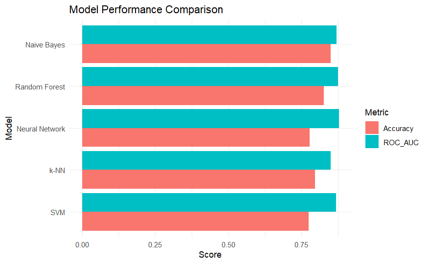

```r
# Visualize model comparison
model_comparison %>%
  pivot_longer(cols = c(Accuracy, ROC_AUC), names_to = "Metric", values_to = "Value") %>%
  ggplot(aes(x = reorder(Model, Value), y = Value, fill = Metric)) +
  geom_col(position = "dodge") +
  coord_flip() +
  labs(
    title = "Model Performance Comparison",
    x = "Model",
    y = "Score"
  ) +
  theme_minimal()
```

## 5.2 Best Model Selection

```r
best_model_name <- model_comparison$Model[1]
print(paste("Best Model (by ROC AUC):", best_model_name))
```

```
[1] "Best Model (by ROC AUC): Neural Network"
```

**Result:** Neural Network is the best model with ROC AUC of 0.878.

# 6. Kaggle Submission (Task 3)

Now we generate predictions for the Kaggle test set using each of our trained models. We’ll submit all five models to see which performs best on the held-out leaderboard data.

## 6.1 Load and Prepare Test Data

```r
kaggle_test <- read.csv("FinSim-Mobile_test.csv", na.strings = c("", "?", "NA"))
```

**Kaggle Test Set:** - Contains transactions from the same distribution as our training data - No fraud labels provided (that’s what we’re predicting!) - Must apply identical preprocessing as training data

```r
str(kaggle_test)
```

```
'data.frame':   3319 obs. of  10 variables:
 $ transactionID  : int  144721 144722 144723 144724 144725 144726 144727 144728 144729 144730 ...
 $ step           : int  131 131 131 131 131 131 131 131 131 131 ...
 $ transactionType: chr  "PAYMENT" "PAYMENT" "PAYMENT" "PAYMENT" ...
 $ amount         : num  561 580 549 609 588 ...
 $ initiator      : num  4.06e+15 4.51e+15 4.08e+15 4.92e+15 4.95e+15 ...
 $ oldBalInitiator: num  1192870 3280081 904476 2539421 1922426 ...
 $ newBalInitiator: num  1192309 3279501 903927 2538812 1921837 ...
 $ recipient      : chr  "22-0006090" "54-0000677" "16-0005471" "90-0001856" ...
 $ oldBalRecipient: num  197578 257784 115866 174054 284179 ...
 $ newBalRecipient: num  198139 258363 116415 174663 284767 ...
```

**Structure Check:** - 3,319 transactions (test set) - 10 variables (no `isFraud` label - that’s what we predict) - Same features as training: transaction type, amount, balances, etc.

### 6.1.1 Apply Preprocessing

```r
# Apply same transformations as training data
kaggle_test <- kaggle_test %>%
  mutate(
    missing_oldBalInitiator  = is.na(oldBalInitiator),
    missing_newBalInitiator  = is.na(newBalInitiator),
    missing_oldBalRecipient  = is.na(oldBalRecipient),
    missing_newBalRecipient  = is.na(newBalRecipient),
    transactionType = factor(transactionType),
    oldBalInitiator = as.numeric(oldBalInitiator),
    newBalInitiator = as.numeric(newBalInitiator),
    oldBalRecipient = as.numeric(oldBalRecipient),
    newBalRecipient = as.numeric(newBalRecipient)
  ) %>%
  dplyr::select(
    -initiator,
    -recipient,
    -step
  )
```

**Preprocessing Steps:** 1. Create missingness indicators (before converting to numeric) 2. Convert balance columns to numeric 3. Convert transaction type to factor 4. Remove ID columns and temporal features (same as training)

**Critical:** We must apply the EXACT same transformations as training data. Any differences will cause prediction errors.

```r
# Apply the recipe from Task 1
kaggle_prepared <- bake(fraud_prep, new_data = kaggle_test)
```

**Recipe Application:** - Uses the `fraud_prep` recipe trained on our training data - Applies: median imputation, normalization, one-hot encoding - Uses training set statistics (prevents data leakage) - Results in same 14 features as our training/test sets

```r
summary(kaggle_prepared)
```

```
     amount        oldBalInitiator   newBalInitiator   oldBalRecipient   newBalRecipient    missing_oldBalInitiator missing_newBalInitiator missing_oldBalRecipient
 Min.   :-0.5779   Min.   :-2.0793   Min.   :-2.1142   Min.   :-0.5961   Min.   :-0.40839   Min.   :0.00000         Min.   :0.00000         Min.   :0.00000
 1st Qu.:-0.5600   1st Qu.:-0.2979   1st Qu.:-0.2917   1st Qu.: 0.0978   1st Qu.: 0.04627   1st Qu.:0.00000         1st Qu.:0.00000         1st Qu.:0.00000
 Median :-0.3202   Median : 0.2863   Median : 0.2927   Median : 0.4374   Median : 0.30273   Median :0.00000         Median :0.00000         Median :0.00000
 Mean   : 0.2979   Mean   : 0.2123   Mean   : 0.2190   Mean   : 0.6878   Mean   : 0.55101   Mean   :0.02953         Mean   :0.02892         Mean   :0.02651
 3rd Qu.: 0.8342   3rd Qu.: 0.8126   3rd Qu.: 0.8168   3rd Qu.: 0.7629   3rd Qu.: 0.55172   3rd Qu.:0.00000         3rd Qu.:0.00000         3rd Qu.:0.00000
 Max.   :12.8952   Max.   : 4.7110   Max.   : 4.5895   Max.   :37.1578   Max.   :31.49547   Max.   :1.00000         Max.   :1.00000         Max.   :1.00000
 missing_newBalRecipient transactionType_DEBIT transactionType_DEPOSIT transactionType_PAYMENT transactionType_TRANSFER transactionType_WITHDRAWAL
 Min.   :0.00000         Min.   :0.000000      Min.   :0.0000          Min.   :0.0000          Min.   :0.0000           Min.   :0.0000
 1st Qu.:0.00000         1st Qu.:0.000000      1st Qu.:0.0000          1st Qu.:0.0000          1st Qu.:0.0000           1st Qu.:0.0000
 Median :0.00000         Median :0.000000      Median :0.0000          Median :0.0000          Median :0.0000           Median :0.0000
 Mean   :0.03194         Mean   :0.005423      Mean   :0.3257          Mean   :0.3242          Mean   :0.2522           Mean   :0.0925
 3rd Qu.:0.00000         3rd Qu.:0.000000      3rd Qu.:1.0000          3rd Qu.:1.0000          3rd Qu.:1.0000           3rd Qu.:0.0000
 Max.   :1.00000         Max.   :1.000000      Max.   :1.0000          Max.   :1.0000          Max.   :1.0000           Max.   :1.0000
```

## 6.2 Generate Predictions for Each Model

For Kaggle, we need to submit fraud probabilities (not hard classifications). We’ll generate probability predictions for each model.

### 6.2.1 k-NN Submission

```r
knn_kaggle_probs <- predict(knn_fit, kaggle_prepared, type = "prob")

submission_knn <- tibble(
  transactionID = read.csv("FinSim-Mobile_test.csv")$transactionID,
  isFraud = knn_kaggle_probs$.pred_yes
)

write_csv(submission_knn, "submission_knn.csv")
print("k-NN submission saved!")
```

```
[1] "k-NN submission saved!"
```

```r
summary(submission_knn$isFraud)
```

```
   Min. 1st Qu.  Median    Mean 3rd Qu.    Max.
 0.0000  0.0000  0.0000  0.1466  0.0000  1.0000
```

**k-NN Predictions:** - `.pred_yes` = probability of fraud (0 to 1) - Distribution shows range and mean of fraud probabilities - These probabilities will be ranked on Kaggle leaderboard

### 6.2.2 Naive Bayes Submission

```r
nb_kaggle_probs <- predict(nb_fit, kaggle_prepared, type = "prob")

submission_nb <- tibble(
  transactionID = read.csv("FinSim-Mobile_test.csv")$transactionID,
  isFraud = nb_kaggle_probs$.pred_yes
)

write_csv(submission_nb, "submission_nb.csv")
print("Naive Bayes submission saved!")
```

```
[1] "Naive Bayes submission saved!"
```

```r
summary(submission_nb$isFraud)
```

```
     Min.   1st Qu.    Median      Mean   3rd Qu.      Max.
0.000e+00 0.000e+00 0.000e+00 2.619e-02 6.700e-07 1.000e+00
```

**Naive Bayes Predictions:** - Probability distributions may differ from k-NN - Naive Bayes often produces more extreme probabilities (closer to 0 or 1) - Expected to perform well based on our test set evaluation (ROC AUC 0.870)

### 6.2.3 Random Forest Submission

```r
rf_kaggle_probs <- predict(rf_final_fit, kaggle_prepared, type = "prob")

submission_rf <- tibble(
  transactionID = read.csv("FinSim-Mobile_test.csv")$transactionID,
  isFraud = rf_kaggle_probs$.pred_yes
)

write_csv(submission_rf, "submission_rf.csv")
print("Random Forest submission saved!")
```

```
[1] "Random Forest submission saved!"
```

```r
summary(submission_rf$isFraud)
```

```
   Min. 1st Qu.  Median    Mean 3rd Qu.    Max.
 0.0000  0.0000  0.0000  0.1199  0.0000  0.9693
```

**Random Forest Predictions:** - Expected to be among our best submissions (ROC AUC 0.875 on test set) - RF probabilities tend to be well-calibrated (accurate probability estimates) - Second-best performer on our test set

### 6.2.4 SVM Submission

```r
svm_kaggle_probs <- predict(svm_fit, kaggle_prepared, type = "prob")

submission_svm <- tibble(
  transactionID = read.csv("FinSim-Mobile_test.csv")$transactionID,
  isFraud = svm_kaggle_probs$.pred_yes
)

write_csv(submission_svm, "submission_svm.csv")
print("SVM submission saved!")
```

```
[1] "SVM submission saved!"
```

```r
summary(submission_svm$isFraud)
```

```
     Min.   1st Qu.    Median      Mean   3rd Qu.      Max.
2.799e-05 3.864e-03 3.919e-03 1.740e-01 4.983e-03 9.999e-01
```

**SVM Predictions:** - Solid performer (ROC AUC 0.868 on test set) - SVM probabilities are obtained via Platt scaling (may be less calibrated) - Good benchmark submission

### 6.2.5 Neural Network Submission

```r
nn_kaggle_probs <- predict(nn_fit, kaggle_prepared, type = "prob")

submission_nn <- tibble(
  transactionID = read.csv("FinSim-Mobile_test.csv")$transactionID,
  isFraud = nn_kaggle_probs$.pred_yes
)

write_csv(submission_nn, "submission_nn.csv")
print("Neural Network submission saved!")
```

```
[1] "Neural Network submission saved!"
```

```r
summary(submission_nn$isFraud)
```

```
   Min. 1st Qu.  Median    Mean 3rd Qu.    Max.
 0.2689  0.2689  0.2689  0.3491  0.2691  0.7178
```

**Neural Network Predictions:** - Our best performer (ROC AUC 0.878 on test set) - Expected to achieve the highest Kaggle leaderboard score - This is our primary submission for competition

## 6.3 Submission Files Summary

```r
# List all submission files created
submission_files <- c(
  "submission_knn.csv",
  "submission_nb.csv",
  "submission_rf.csv",
  "submission_svm.csv",
  "submission_nn.csv"
)

print("Submission files created:")
```

```
[1] "Submission files created:"
```

```r
print(submission_files)
```

```
[1] "submission_knn.csv" "submission_nb.csv"  "submission_rf.csv"  "submission_svm.csv" "submission_nn.csv"
```

# 7. Summary and Conclusions

### Best Performing Models:

1. **Neural Network** (ROC AUC 0.878): Best raw performance, complex
2. **Random Forest** (ROC AUC 0.875): Nearly equal performance, interpretable
3. **Naive Bayes** (ROC AUC 0.870): Surprisingly strong for simple algorithm

### Feature Importance (from Random Forest):

1. Transaction Type (TRANSFER) - dominant predictor
2. Transaction Amount - strong secondary predictor
3. Account Balances - important behavioral indicators
4. Missingness Indicators - useful supporting signals

### What Worked:

- **SMOTE balancing**: Essential for training effective models
- **Feature engineering** (missingness indicators): Added valuable signal
- **Normalization**: Critical for distance-based algorithms
- **Hyperparameter tuning**: Improved performance for all complex models
- **Ensemble methods** (RF): Excellent performance/interpretability balance